# WiSTEM 2022 - 2023

## February 24, 2023

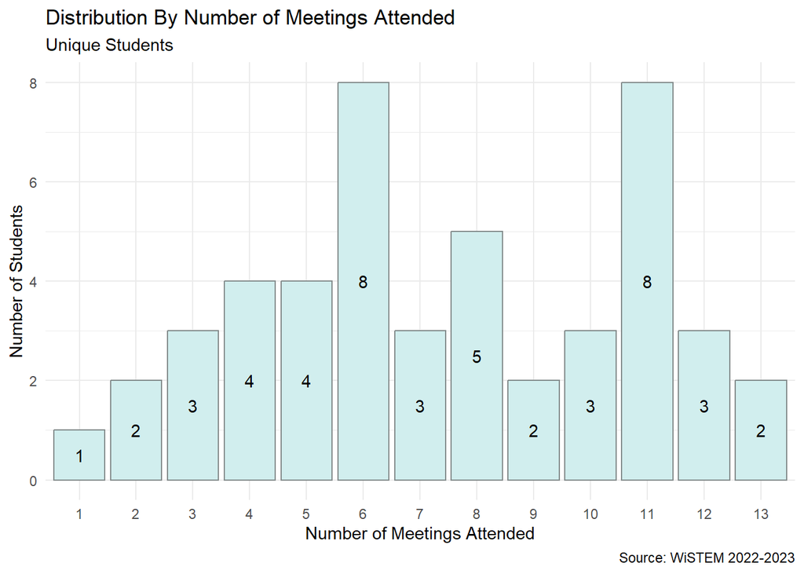

**Table for Number of Meetings Attended for February 24th**

Attendance Distribution By Number of Meetings Attended

| num_meetings | num_students | prop | percent |
| --- | --- | --- | --- |
| 1 | 1 | 0.0208333 | 2.083333 |
| 2 | 2 | 0.0416667 | 4.166667 |
| 3 | 3 | 0.0625000 | 6.250000 |
| 4 | 4 | 0.0833333 | 8.333333 |
| 5 | 4 | 0.0833333 | 8.333333 |
| 6 | 8 | 0.1666667 | 16.666667 |
| 7 | 3 | 0.0625000 | 6.250000 |
| 8 | 5 | 0.1041667 | 10.416667 |
| 9 | 2 | 0.0416667 | 4.166667 |
| 10 | 3 | 0.0625000 | 6.250000 |
| 11 | 8 | 0.1666667 | 16.666667 |
| 12 | 3 | 0.0625000 | 6.250000 |
| 13 | 2 | 0.0416667 | 4.166667 |

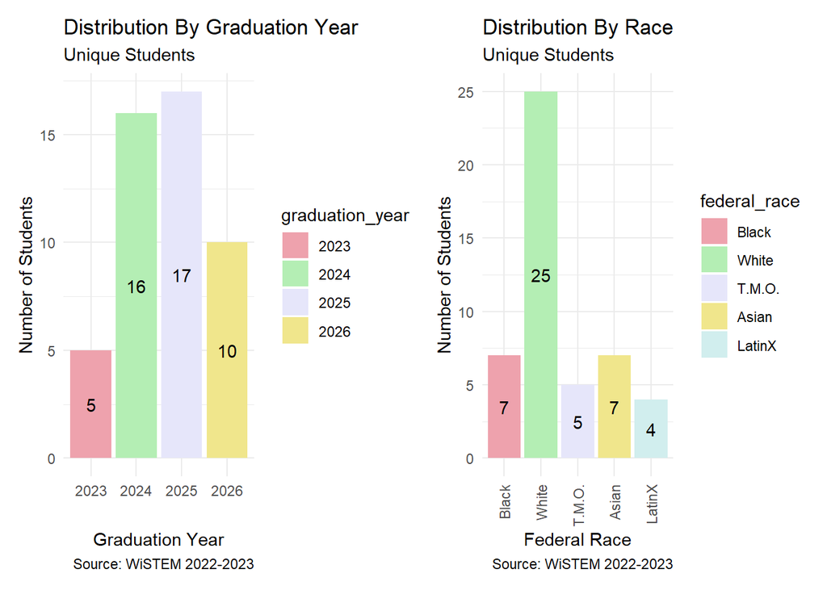

**Table for Graduation Race for February 24th**

Attendance Distribution By Graduation Year

| graduation_year | num_students | prop | percent |
| --- | --- | --- | --- |
| 2023 | 5 | 0.1041667 | 10.41667 |
| 2024 | 16 | 0.3333333 | 33.33333 |
| 2025 | 17 | 0.3541667 | 35.41667 |
| 2026 | 10 | 0.2083333 | 20.83333 |

**Table for Federal Race for February 24th**

Attendance Distribution By Federal Race

| federal_race | num_students | prop | percent |
| --- | --- | --- | --- |
| Black | 7 | 0.1458333 | 14.583333 |
| White | 25 | 0.5208333 | 52.083333 |
| T.M.O. | 5 | 0.1041667 | 10.416667 |
| Asian | 7 | 0.1458333 | 14.583333 |
| LatinX | 4 | 0.0833333 | 8.333333 |

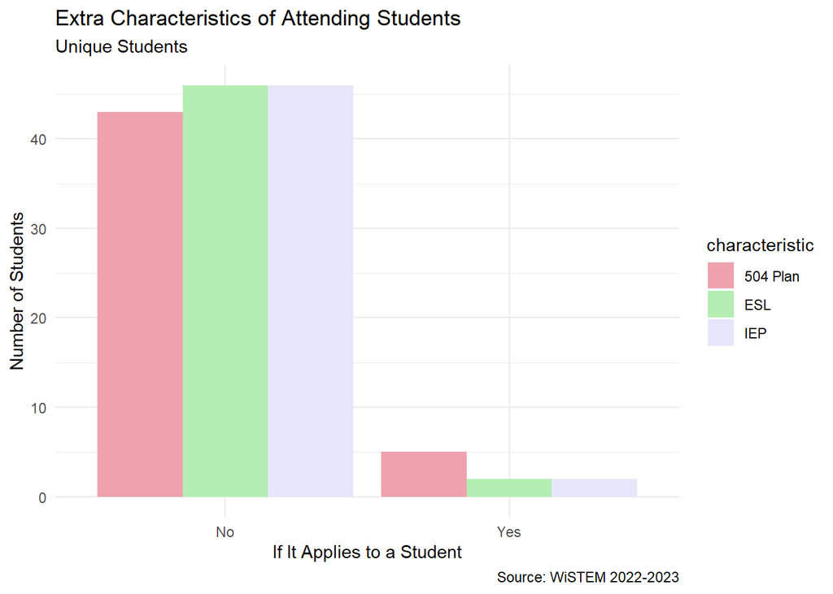

**Table for Additional Characteristics for February 24th**

Attendance Distribution by Additional Characteristics

| characteristic | applicable | num_students | prop | percent |
| --- | --- | --- | --- | --- |
| IEP | Yes | 2 | 0.0138889 | 1.388889 |
| IEP | No | 46 | 0.3194444 | 31.944444 |
| 504 Plan | Yes | 5 | 0.0347222 | 3.472222 |
| 504 Plan | No | 43 | 0.2986111 | 29.861111 |
| ESL | Yes | 2 | 0.0138889 | 1.388889 |
| ESL | No | 46 | 0.3194444 | 31.944444 |

## March 31, 2023

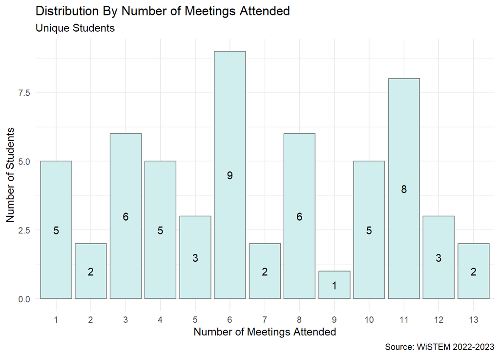

**Table for Number of Meetings Attended for March 31st**

Attendance Distribution By Number of Meetings Attended

| num_meetings | num_students | prop | percent |
| --- | --- | --- | --- |
| 1 | 5 | 0.0877193 | 8.771930 |
| 2 | 2 | 0.0350877 | 3.508772 |
| 3 | 6 | 0.1052632 | 10.526316 |
| 4 | 5 | 0.0877193 | 8.771930 |
| 5 | 3 | 0.0526316 | 5.263158 |
| 6 | 9 | 0.1578947 | 15.789474 |
| 7 | 2 | 0.0350877 | 3.508772 |
| 8 | 6 | 0.1052632 | 10.526316 |
| 9 | 1 | 0.0175439 | 1.754386 |
| 10 | 5 | 0.0877193 | 8.771930 |
| 11 | 8 | 0.1403509 | 14.035088 |
| 12 | 3 | 0.0526316 | 5.263158 |
| 13 | 2 | 0.0350877 | 3.508772 |

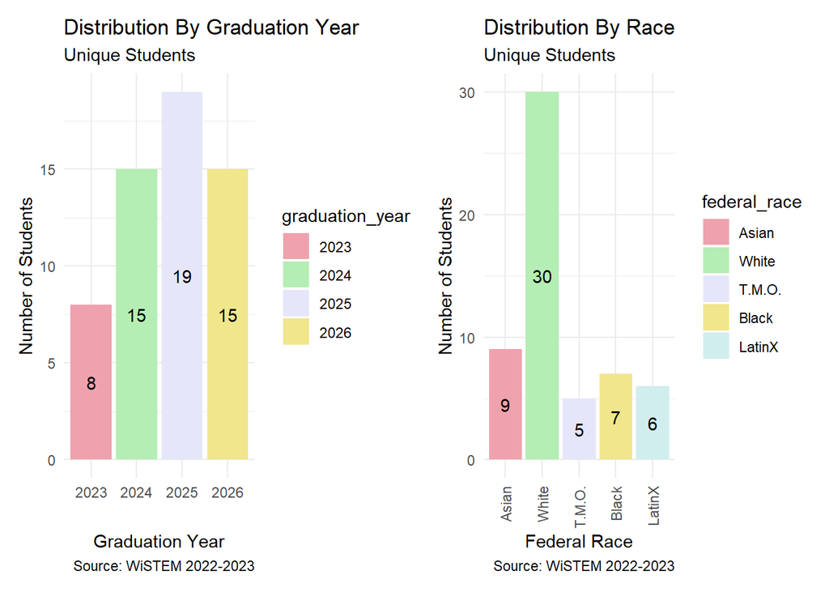

**Table for Graduation Race for March 31st**

Attendance Distribution By Graduation Year

| graduation_year | num_students | prop | percent |
| --- | --- | --- | --- |
| 2023 | 8 | 0.1403509 | 14.03509 |
| 2024 | 15 | 0.2631579 | 26.31579 |
| 2025 | 19 | 0.3333333 | 33.33333 |
| 2026 | 15 | 0.2631579 | 26.31579 |

**Table for Federal Race for March 31st**

Attendance Distribution By Federal Race

| federal_race | num_students | prop | percent |
| --- | --- | --- | --- |
| Asian | 9 | 0.1578947 | 15.78947 |
| White | 30 | 0.5263158 | 52.63158 |
| T.M.O. | 5 | 0.0877193 | 8.77193 |
| Black | 7 | 0.1228070 | 12.28070 |
| LatinX | 6 | 0.1052632 | 10.52632 |

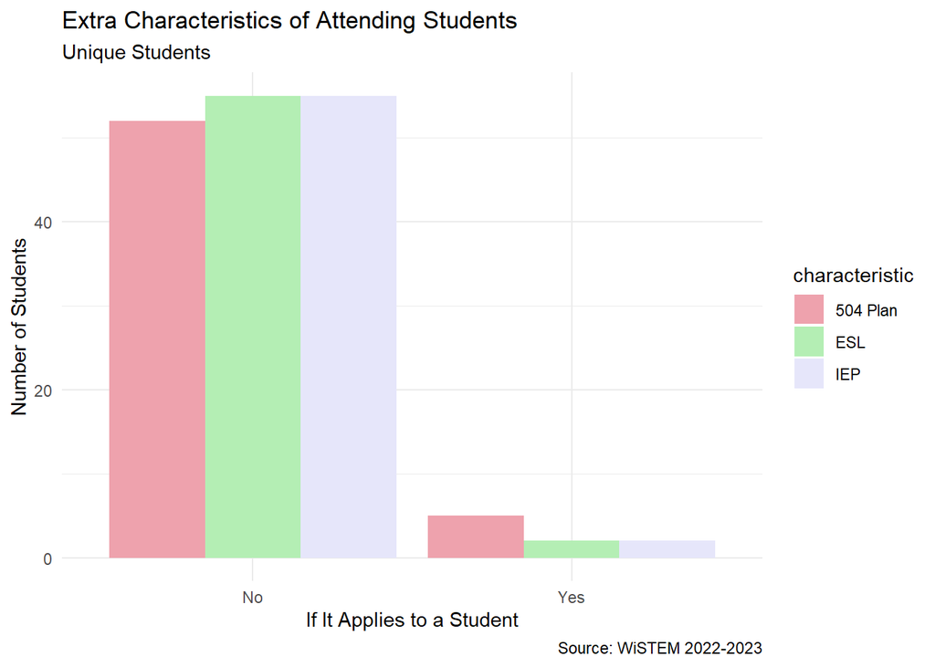

**Table for Additional Characteristics for March 31st**

Attendance Distribution by Additional Characteristics

| characteristic | applicable | num_students | prop | percent |
| --- | --- | --- | --- | --- |
| IEP | Yes | 2 | 0.0116959 | 1.169591 |
| IEP | No | 55 | 0.3216374 | 32.163743 |
| 504 Plan | Yes | 5 | 0.0292398 | 2.923977 |
| 504 Plan | No | 52 | 0.3040936 | 30.409357 |
| ESL | Yes | 2 | 0.0116959 | 1.169591 |
| ESL | No | 55 | 0.3216374 | 32.163743 |

## April 14, 2023

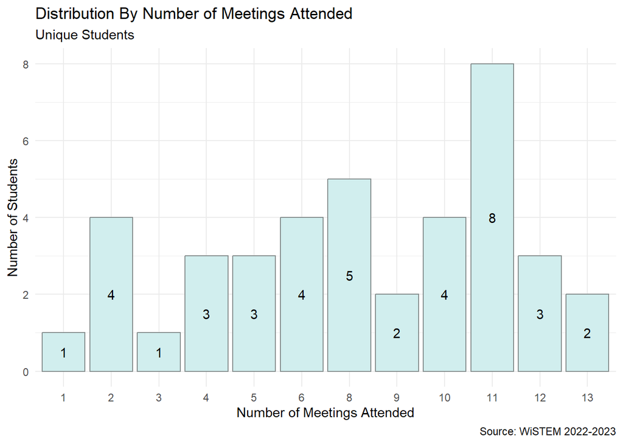

**Table for Number of Meetings Attended for April 14th**

Attendance Distribution By Number of Meetings Attended

| num_meetings | num_students | prop | percent |
| --- | --- | --- | --- |
| 1 | 1 | 0.025 | 2.5 |
| 2 | 4 | 0.100 | 10.0 |
| 3 | 1 | 0.025 | 2.5 |
| 4 | 3 | 0.075 | 7.5 |
| 5 | 3 | 0.075 | 7.5 |
| 6 | 4 | 0.100 | 10.0 |
| 8 | 5 | 0.125 | 12.5 |
| 9 | 2 | 0.050 | 5.0 |
| 10 | 4 | 0.100 | 10.0 |
| 11 | 8 | 0.200 | 20.0 |
| 12 | 3 | 0.075 | 7.5 |
| 13 | 2 | 0.050 | 5.0 |

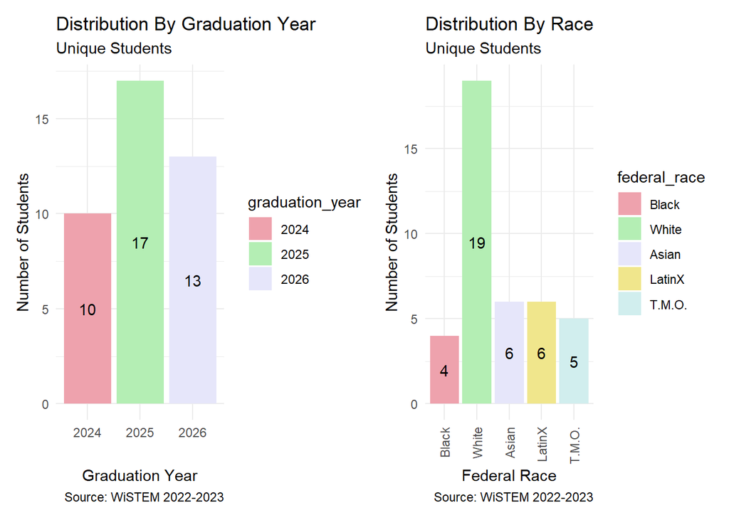

**Table for Graduation Race for April 14th**

Attendance Distribution By Graduation Year

| graduation_year | num_students | prop | percent |
| --- | --- | --- | --- |
| 2024 | 10 | 0.250 | 25.0 |
| 2025 | 17 | 0.425 | 42.5 |
| 2026 | 13 | 0.325 | 32.5 |

**Table for Federal Race for April 14th**

Attendance Distribution By Federal Race

| federal_race | num_students | prop | percent |
| --- | --- | --- | --- |
| Black | 4 | 0.100 | 10.0 |
| White | 19 | 0.475 | 47.5 |
| Asian | 6 | 0.150 | 15.0 |
| LatinX | 6 | 0.150 | 15.0 |
| T.M.O. | 5 | 0.125 | 12.5 |

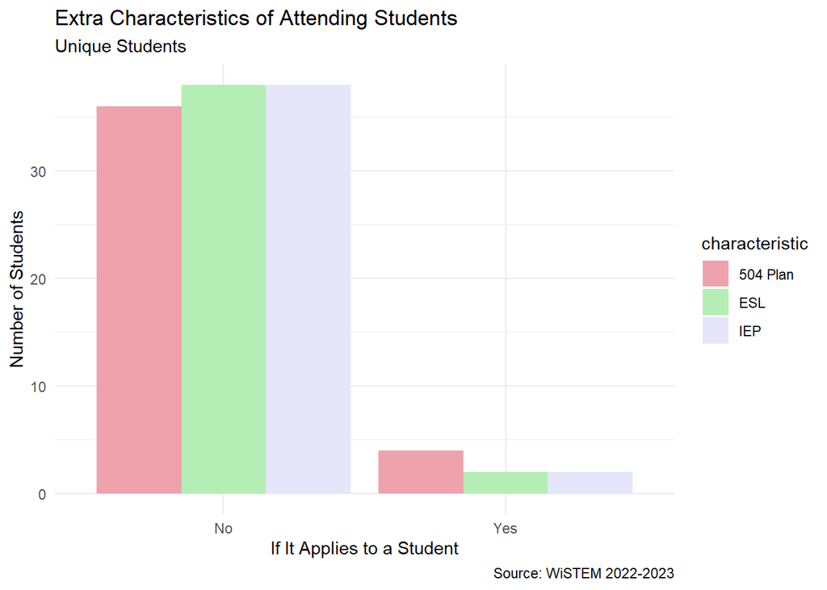

**Table for Additional Characteristics for April 14th**

Attendance Distribution by Additional Characteristics

| characteristic | applicable | num_students | prop | percent |
| --- | --- | --- | --- | --- |
| IEP | Yes | 2 | 0.0166667 | 1.666667 |
| IEP | No | 38 | 0.3166667 | 31.666667 |
| 504 Plan | Yes | 4 | 0.0333333 | 3.333333 |
| 504 Plan | No | 36 | 0.3000000 | 30.000000 |
| ESL | Yes | 2 | 0.0166667 | 1.666667 |
| ESL | No | 38 | 0.3166667 | 31.666667 |

## April 28, 2023

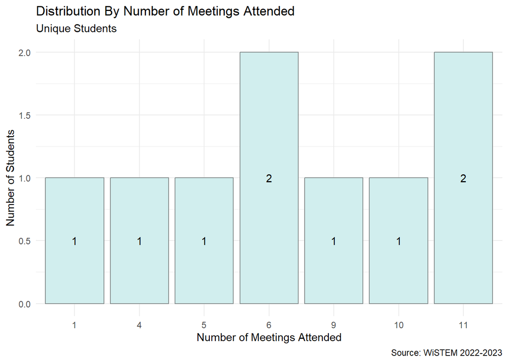

**Table for Number of Meetings Attended for April 28th**

Attendance Distribution By Number of Meetings Attended

| num_meetings | num_students | prop | percent |
| --- | --- | --- | --- |
| 1 | 1 | 0.1111111 | 11.11111 |
| 4 | 1 | 0.1111111 | 11.11111 |
| 5 | 1 | 0.1111111 | 11.11111 |
| 6 | 2 | 0.2222222 | 22.22222 |
| 9 | 1 | 0.1111111 | 11.11111 |
| 10 | 1 | 0.1111111 | 11.11111 |
| 11 | 2 | 0.2222222 | 22.22222 |

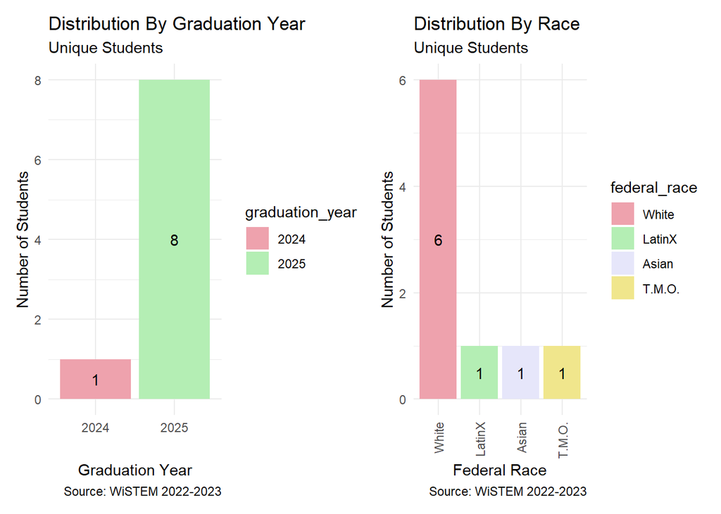

**Table for Graduation Race for April 28th**

Attendance Distribution By Graduation Year

| graduation_year | num_students | prop | percent |
| --- | --- | --- | --- |
| 2024 | 1 | 0.1111111 | 11.11111 |
| 2025 | 8 | 0.8888889 | 88.88889 |

**Table for Federal Race for April 28th**

Attendance Distribution By Federal Race

| federal_race | num_students | prop | percent |
| --- | --- | --- | --- |
| White | 6 | 0.6666667 | 66.66667 |
| LatinX | 1 | 0.1111111 | 11.11111 |
| Asian | 1 | 0.1111111 | 11.11111 |
| T.M.O. | 1 | 0.1111111 | 11.11111 |

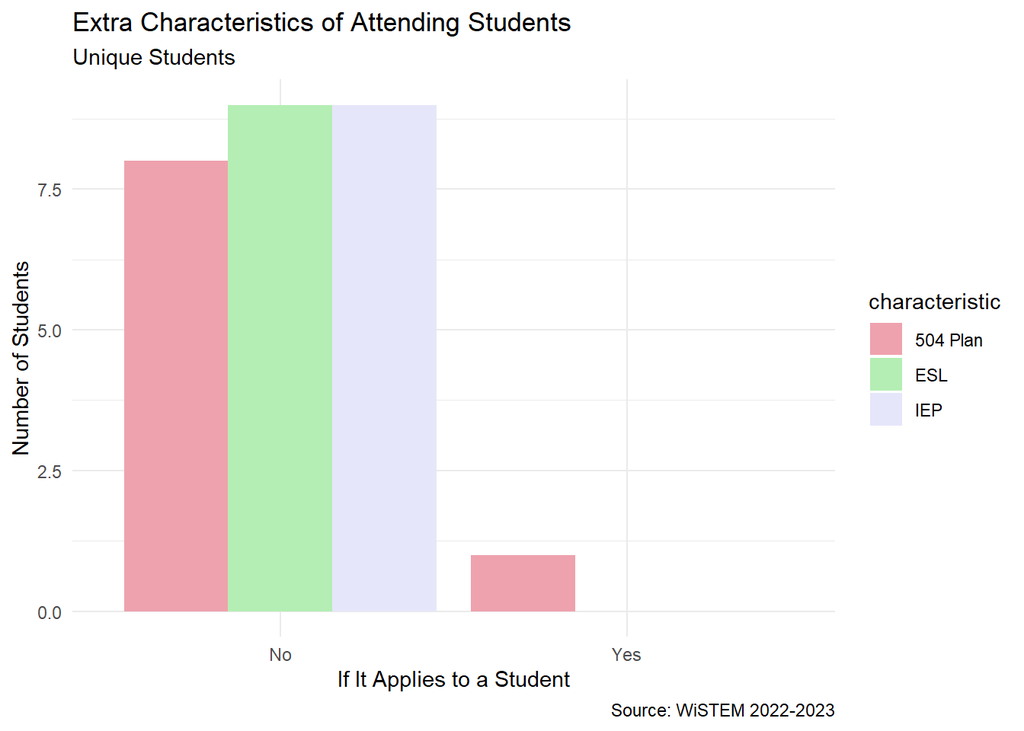

**Table for Additional Characteristics for April 28th**

Attendance Distribution by Additional Characteristics

| characteristic | applicable | num_students | prop | percent |
| --- | --- | --- | --- | --- |
| IEP | Yes | NA | NA | NA |
| IEP | No | 9 | NA | NA |
| 504 Plan | Yes | 1 | NA | NA |
| 504 Plan | No | 8 | NA | NA |
| ESL | Yes | NA | NA | NA |
| ESL | No | 9 | NA | NA |

## May 12, 2023

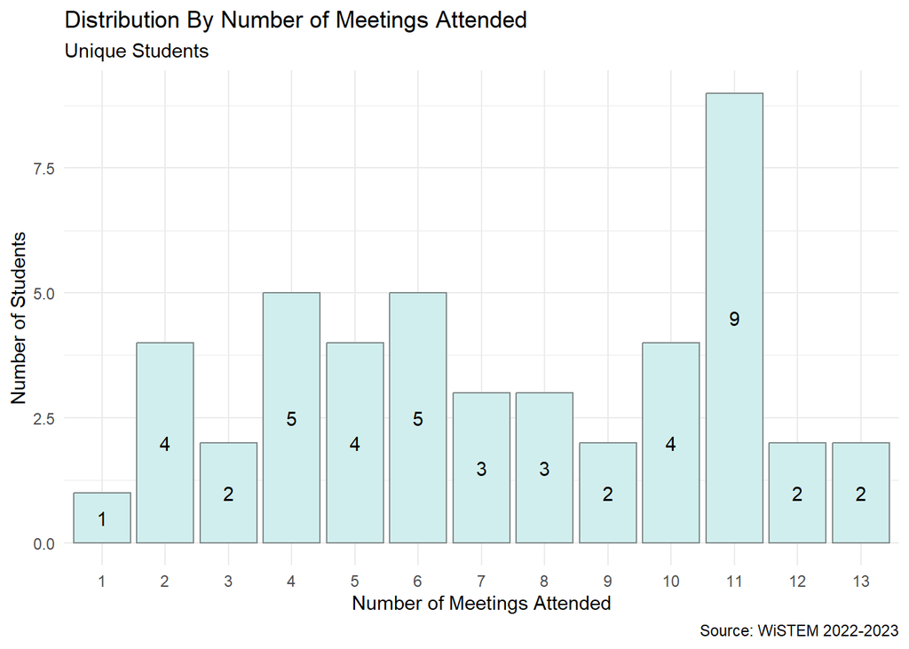

**Table for Number of Meetings Attended for May 12th**

Attendance Distribution By Number of Meetings Attended

| num_meetings | num_students | prop | percent |
| --- | --- | --- | --- |
| 1 | 1 | 0.0217391 | 2.173913 |
| 2 | 4 | 0.0869565 | 8.695652 |
| 3 | 2 | 0.0434783 | 4.347826 |
| 4 | 5 | 0.1086957 | 10.869565 |
| 5 | 4 | 0.0869565 | 8.695652 |
| 6 | 5 | 0.1086957 | 10.869565 |
| 7 | 3 | 0.0652174 | 6.521739 |
| 8 | 3 | 0.0652174 | 6.521739 |
| 9 | 2 | 0.0434783 | 4.347826 |
| 10 | 4 | 0.0869565 | 8.695652 |
| 11 | 9 | 0.1956522 | 19.565217 |
| 12 | 2 | 0.0434783 | 4.347826 |
| 13 | 2 | 0.0434783 | 4.347826 |

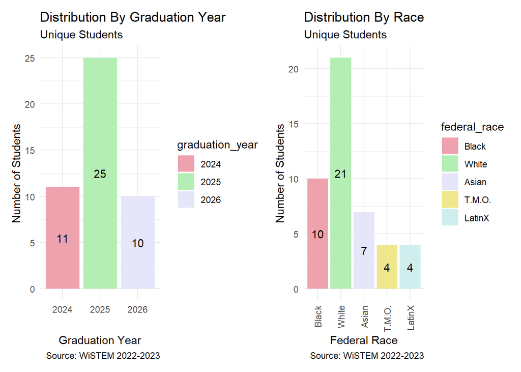

**Table for Graduation Race for May 12th**

Attendance Distribution By Graduation Year

| graduation_year | num_students | prop | percent |
| --- | --- | --- | --- |
| 2024 | 11 | 0.2391304 | 23.91304 |
| 2025 | 25 | 0.5434783 | 54.34783 |
| 2026 | 10 | 0.2173913 | 21.73913 |

**Table for Federal Race for May 12th**

Attendance Distribution By Federal Race

| federal_race | num_students | prop | percent |
| --- | --- | --- | --- |
| Black | 10 | 0.2173913 | 21.739130 |
| White | 21 | 0.4565217 | 45.652174 |
| Asian | 7 | 0.1521739 | 15.217391 |
| T.M.O. | 4 | 0.0869565 | 8.695652 |
| LatinX | 4 | 0.0869565 | 8.695652 |

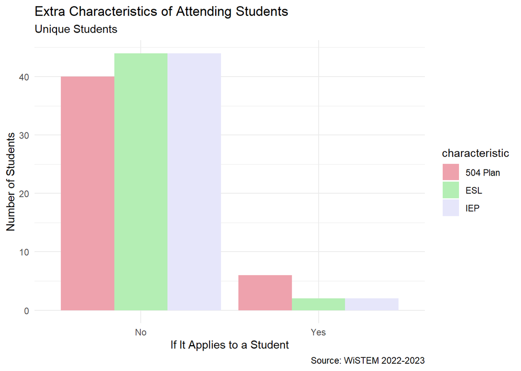

**Table for Additional Characteristics for May 12th**

Attendance Distribution by Additional Characteristics

| characteristic | applicable | num_students | prop | percent |
| --- | --- | --- | --- | --- |
| IEP | Yes | 2 | 0.0144928 | 1.449275 |
| IEP | No | 44 | 0.3188406 | 31.884058 |
| 504 Plan | Yes | 6 | 0.0434783 | 4.347826 |
| 504 Plan | No | 40 | 0.2898551 | 28.985507 |
| ESL | Yes | 2 | 0.0144928 | 1.449275 |
| ESL | No | 44 | 0.3188406 | 31.884058 |

# Attendance by Graduation Year

## Total Grade Distribution

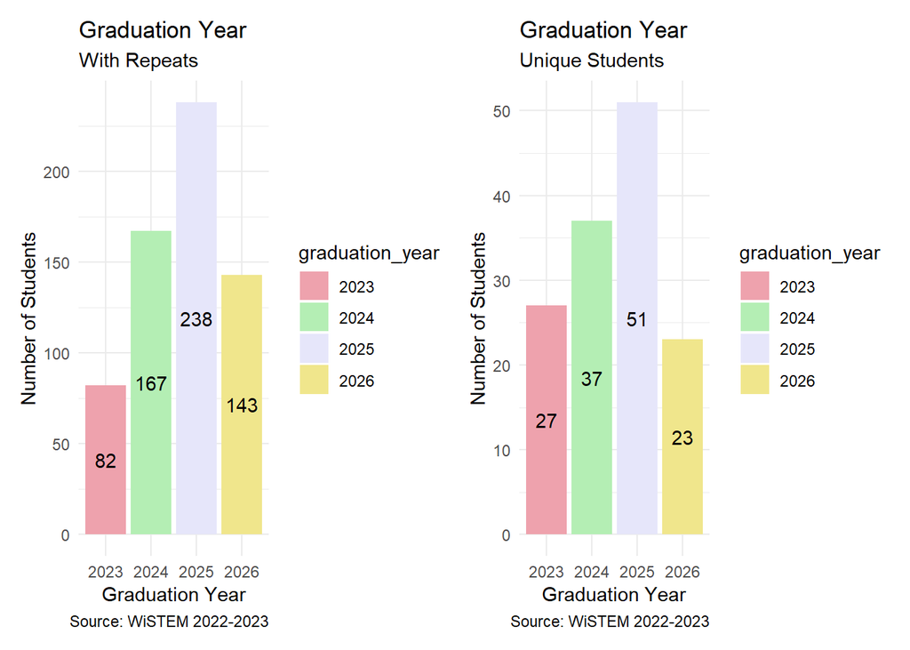

**Table for Graduation Year of All Students (With Repeats)**

Graduation Year of All Students (With Repeats)

| graduation_year | num_students | prop | percent |
| --- | --- | --- | --- |
| 2023 | 82 | 0.1301587 | 13.01587 |
| 2024 | 167 | 0.2650794 | 26.50794 |
| 2025 | 238 | 0.3777778 | 37.77778 |
| 2026 | 143 | 0.2269841 | 22.69841 |

**Table for Graduation Year of All Students (Unique)**

Graduation Year of All Students (Unique)

| graduation_year | num_students | prop | percent |
| --- | --- | --- | --- |
| 2023 | 27 | 0.1956522 | 19.56522 |
| 2024 | 37 | 0.2681159 | 26.81159 |
| 2025 | 51 | 0.3695652 | 36.95652 |
| 2026 | 23 | 0.1666667 | 16.66667 |

## Comparing Grade Distributions with ETHS

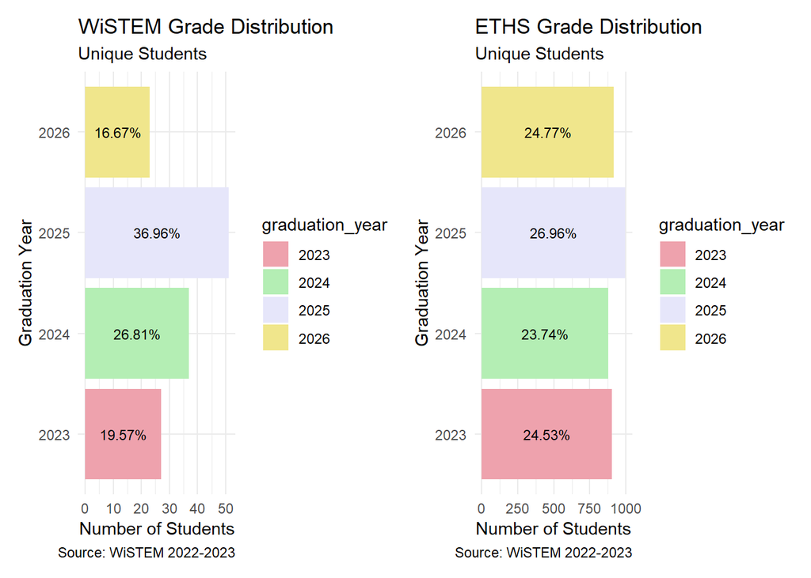

**Table for Comparing Grade Distributions Between WiSTEM and ETHS**

Comparing Grade Distributions (Unique)

| program | graduation_year | num_students | prop | percent |
| --- | --- | --- | --- | --- |
| eths | 2026 | 914 | 0.2476965 | 24.76965 |
| eths | 2025 | 995 | 0.2696477 | 26.96477 |
| eths | 2024 | 876 | 0.2373984 | 23.73984 |
| eths | 2023 | 905 | 0.2452575 | 24.52575 |
| wistem | 2026 | 23 | 0.1666667 | 16.66667 |
| wistem | 2025 | 51 | 0.3695652 | 36.95652 |
| wistem | 2024 | 37 | 0.2681159 | 26.81159 |
| wistem | 2023 | 27 | 0.1956522 | 19.56522 |

## Graduation Year and Number of Meetings

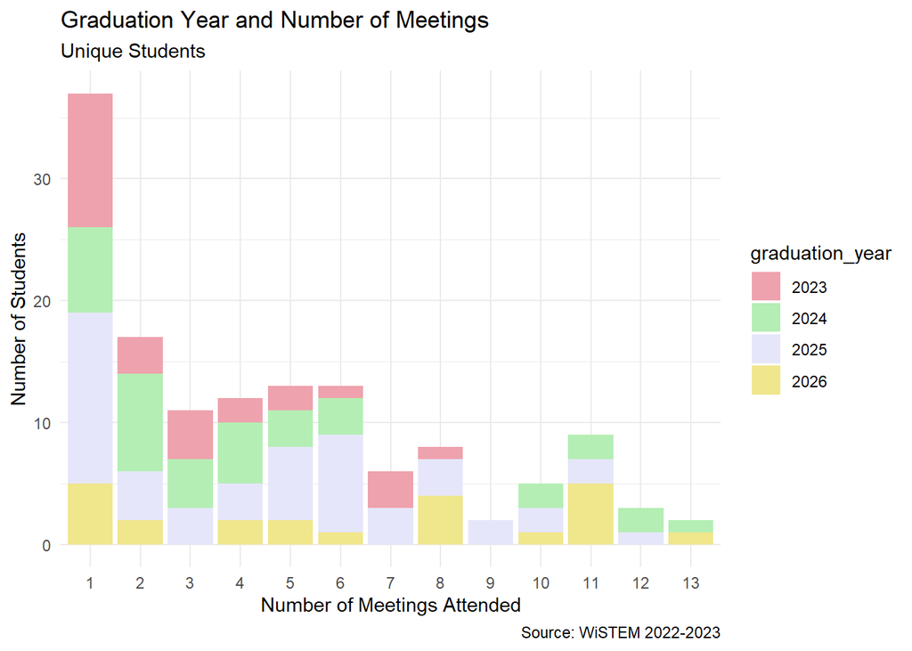

**Table for Graduation Year and Number of Meetings Attended**

Graduation Year and Number of Meetings Attended (Unique)

| num_meetings | 2023 | 2024 | 2025 | 2026 |
| --- | --- | --- | --- | --- |
| 1 | 11 | 7 | 14 | 5 |
| 2 | 3 | 8 | 4 | 2 |
| 3 | 4 | 4 | 3 | NA |
| 4 | 2 | 5 | 3 | 2 |
| 5 | 2 | 3 | 6 | 2 |
| 6 | 1 | 3 | 8 | 1 |
| 7 | 3 | NA | 3 | NA |
| 8 | 1 | NA | 3 | 4 |
| 10 | NA | 2 | 2 | 1 |
| 11 | NA | 2 | 2 | 5 |
| 12 | NA | 2 | 1 | NA |
| 13 | NA | 1 | NA | 1 |
| 9 | NA | NA | 2 | NA |

## Graduation Year and Federal Race

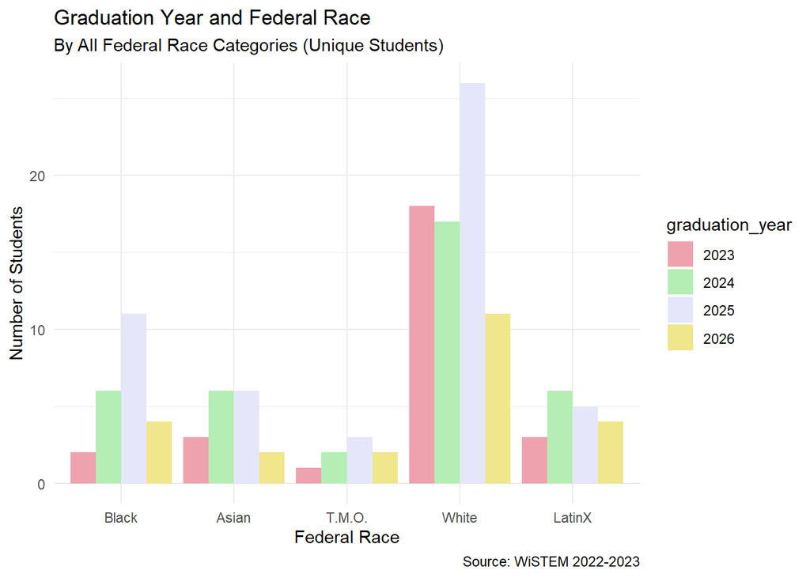

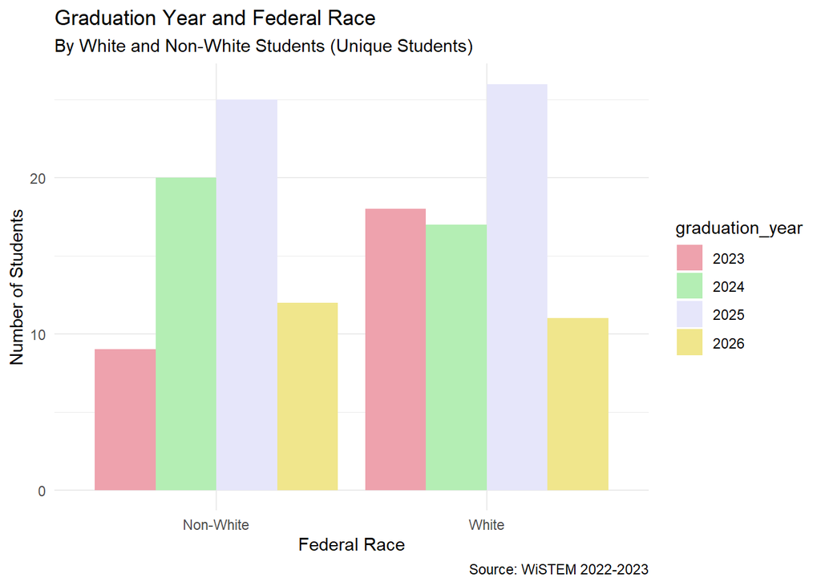

**Table for Graduation Year and Federal Race (Simple)**

Graduation Year and Federal Race (Unique)

| graduation_year | White | Black | Asian | LatinX | T.M.O. |
| --- | --- | --- | --- | --- | --- |
| 2023 | 18 | 2 | 3 | 3 | 1 |
| 2024 | 17 | 6 | 6 | 6 | 2 |
| 2025 | 26 | 11 | 6 | 5 | 3 |
| 2026 | 11 | 4 | 2 | 4 | 2 |

Graduation Year and Federal Race (Unique)

| graduation_year | Non-White | White |
| --- | --- | --- |
| 2023 | 9 | 18 |
| 2024 | 20 | 17 |
| 2025 | 25 | 26 |
| 2026 | 12 | 11 |

**Table for Graduation Year and Federal Race (By Year)**

**Table for 2023 Graduation Year and Federal Race**

2023 Graduation Year and Federal Race (Unique)

| graduation_year | federal_race | num_students | prop | percent |
| --- | --- | --- | --- | --- |
| 2023 | Black | 2 | 0.0740741 | 7.407407 |
| 2023 | Asian | 3 | 0.1111111 | 11.111111 |
| 2023 | T.M.O. | 1 | 0.0370370 | 3.703704 |
| 2023 | White | 18 | 0.6666667 | 66.666667 |
| 2023 | LatinX | 3 | 0.1111111 | 11.111111 |

2023 Graduation Year and Federal Race (Unique)

| graduation_year | federal_race | num_students | prop | percent |
| --- | --- | --- | --- | --- |
| 2023 | Non-White | 9 | 0.3333333 | 33.33333 |
| 2023 | White | 18 | 0.6666667 | 66.66667 |

**Table for 2024 Graduation Year and Federal Race**

2024 Graduation Year and Federal Race (Unique)

| graduation_year | federal_race | num_students | prop | percent |
| --- | --- | --- | --- | --- |
| 2024 | Black | 6 | 0.1621622 | 16.216216 |
| 2024 | Asian | 6 | 0.1621622 | 16.216216 |
| 2024 | T.M.O. | 2 | 0.0540541 | 5.405405 |
| 2024 | White | 17 | 0.4594595 | 45.945946 |
| 2024 | LatinX | 6 | 0.1621622 | 16.216216 |

2024 Graduation Year and Federal Race (Unique)

| graduation_year | federal_race | num_students | prop | percent |
| --- | --- | --- | --- | --- |
| 2024 | Non-White | 20 | 0.5405405 | 54.05405 |
| 2024 | White | 17 | 0.4594595 | 45.94595 |

**Table for 2025 Graduation Year and Federal Race**

2025 Graduation Year and Federal Race (Unique)

| graduation_year | federal_race | num_students | prop | percent |
| --- | --- | --- | --- | --- |
| 2025 | Black | 11 | 0.2156863 | 21.568628 |
| 2025 | Asian | 6 | 0.1176471 | 11.764706 |
| 2025 | T.M.O. | 3 | 0.0588235 | 5.882353 |
| 2025 | White | 26 | 0.5098039 | 50.980392 |
| 2025 | LatinX | 5 | 0.0980392 | 9.803922 |

2025 Graduation Year and Federal Race (Unique)

| graduation_year | federal_race | num_students | prop | percent |
| --- | --- | --- | --- | --- |
| 2025 | Non-White | 25 | 0.4901961 | 49.01961 |
| 2025 | White | 26 | 0.5098039 | 50.98039 |

**Table for 2026 Graduation Year and Federal Race**

2026 Graduation Year and Federal Race (Unique)

| graduation_year | federal_race | num_students | prop | percent |
| --- | --- | --- | --- | --- |
| 2026 | Black | 4 | 0.1739130 | 17.391304 |
| 2026 | Asian | 2 | 0.0869565 | 8.695652 |
| 2026 | T.M.O. | 2 | 0.0869565 | 8.695652 |
| 2026 | White | 11 | 0.4782609 | 47.826087 |
| 2026 | LatinX | 4 | 0.1739130 | 17.391304 |

2026 Graduation Year and Federal Race (Unique)

| graduation_year | federal_race | num_students | prop | percent |
| --- | --- | --- | --- | --- |
| 2026 | Non-White | 12 | 0.5217391 | 52.17391 |
| 2026 | White | 11 | 0.4782609 | 47.82609 |

## Graduation Year and Topic

[figure not shown]

**Table for Graduation Year and Topic (Simple)**

Graduation Year and Topic (With Repeats)

| graduation_year | Activity | Discussion | Guest / Discussion | Guest Speaker | Out of School Event |
| --- | --- | --- | --- | --- | --- |
| 2023 | 55 | 14 | NA | 13 | NA |
| 2024 | 101 | 26 | 11 | 28 | 1 |
| 2025 | 134 | 33 | 25 | 38 | 8 |
| 2026 | 81 | 23 | 10 | 29 | NA |

**Table for Graduation Year and Topic (By Year)**

**Table for 2023 Graduation Year and Topic**

2023 Graduation Year and Topic (With Repeats)

| graduation_year | topic | num_students | prop | percent |
| --- | --- | --- | --- | --- |
| 2023 | Activity | 55 | 0.6707317 | 67.07317 |
| 2023 | Discussion | 14 | 0.1707317 | 17.07317 |
| 2023 | Guest Speaker | 13 | 0.1585366 | 15.85366 |

**Table for 2024 Graduation Year and Topic**

2024 Graduation Year and Topic (With Repeats)

| graduation_year | topic | num_students | prop | percent |
| --- | --- | --- | --- | --- |
| 2024 | Activity | 101 | 0.6047904 | 60.4790419 |
| 2024 | Discussion | 26 | 0.1556886 | 15.5688623 |
| 2024 | Guest / Discussion | 11 | 0.0658683 | 6.5868263 |
| 2024 | Guest Speaker | 28 | 0.1676647 | 16.7664671 |
| 2024 | Out of School Event | 1 | 0.0059880 | 0.5988024 |

**Table for 2025 Graduation Year and Topic**

2025 Graduation Year and Topic (With Repeats)

| graduation_year | topic | num_students | prop | percent |
| --- | --- | --- | --- | --- |
| 2025 | Activity | 134 | 0.5654008 | 56.540084 |
| 2025 | Discussion | 33 | 0.1392405 | 13.924051 |
| 2025 | Guest / Discussion | 25 | 0.1054852 | 10.548523 |
| 2025 | Guest Speaker | 38 | 0.1603376 | 16.033755 |
| 2025 | Out of School Event | 8 | 0.0337553 | 3.375527 |

**Table for 2026 Graduation Year and Topic**

2026 Graduation Year and Topic (With Repeats)

| graduation_year | topic | num_students | prop | percent |
| --- | --- | --- | --- | --- |
| 2026 | Activity | 81 | 0.5704225 | 57.042254 |
| 2026 | Discussion | 23 | 0.1619718 | 16.197183 |
| 2026 | Guest / Discussion | 10 | 0.0704225 | 7.042254 |
| 2026 | Guest Speaker | 29 | 0.2042254 | 20.422535 |

# Attendance by Federal Race

## Total Race Distribution

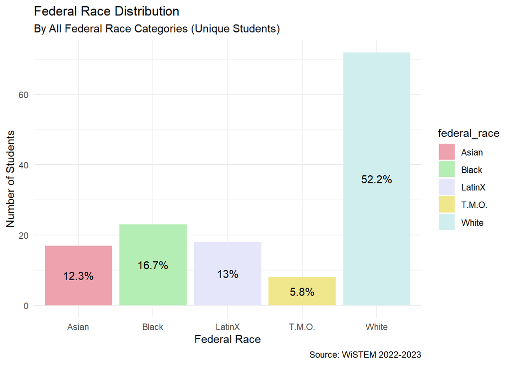

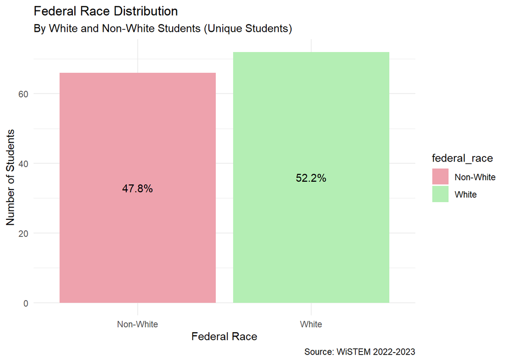

**Table for Total Race Distribution**

Federal Race Distribution (Unique)

| federal_race | num_students | prop | percent |
| --- | --- | --- | --- |
| Asian | 17 | 0.1231884 | 12.318841 |
| Black | 23 | 0.1666667 | 16.666667 |
| LatinX | 18 | 0.1304348 | 13.043478 |
| T.M.O. | 8 | 0.0579710 | 5.797101 |
| White | 72 | 0.5217391 | 52.173913 |

Federal Race Distribution With Only White and Non-White (Unique)

| federal_race | num_students | prop | percent |
| --- | --- | --- | --- |
| Non-White | 66 | 0.4782609 | 47.82609 |
| White | 72 | 0.5217391 | 52.17391 |

## Race Distribution Without One-Timers

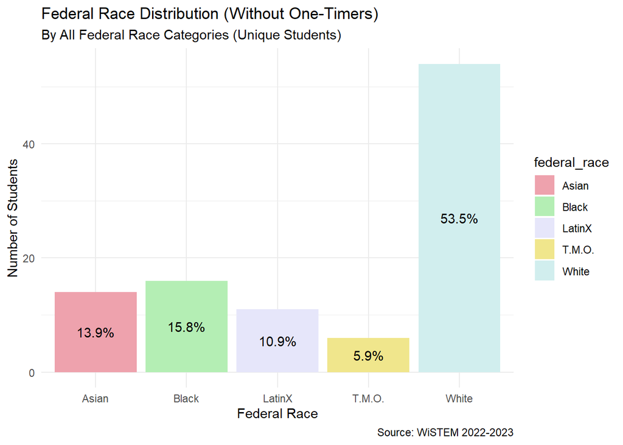

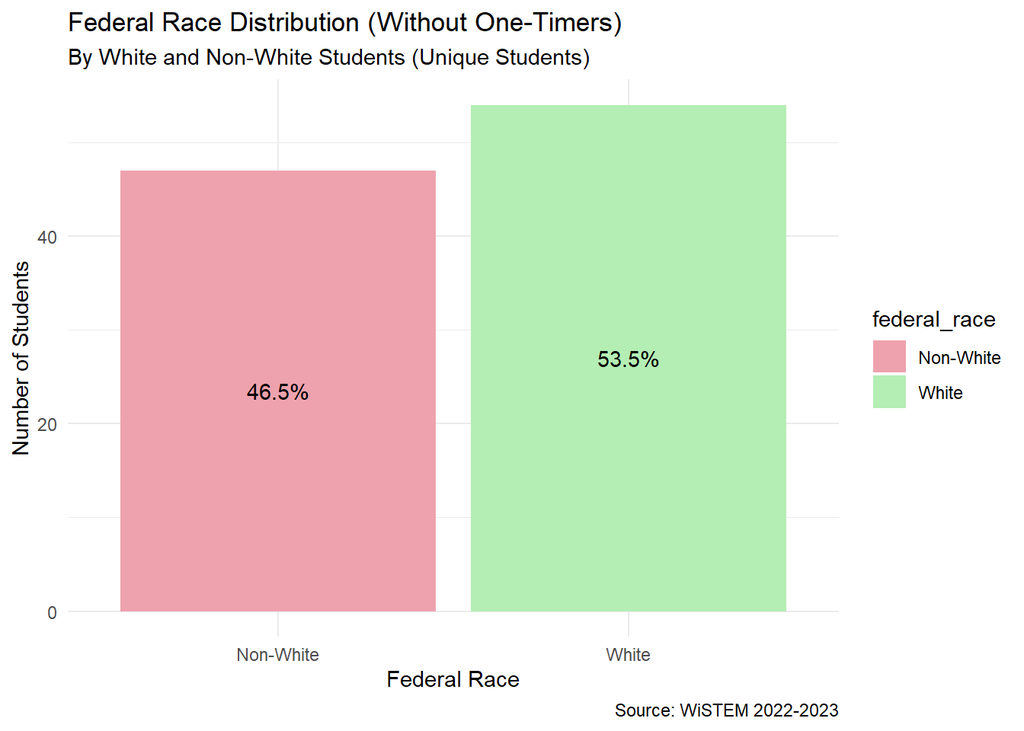

**Table for Total Race Distribution Without One-Timers**

Federal Race Distribution Without One-Timers (Unique)

| federal_race | num_students | prop | percent |
| --- | --- | --- | --- |
| Asian | 14 | 0.1386139 | 13.861386 |
| Black | 16 | 0.1584158 | 15.841584 |
| LatinX | 11 | 0.1089109 | 10.891089 |
| T.M.O. | 6 | 0.0594059 | 5.940594 |
| White | 54 | 0.5346535 | 53.465347 |

Federal Race Distribution Without One-Timers (Only White and Non-White; Unique)

| federal_race | num_students | prop | percent |
| --- | --- | --- | --- |
| Non-White | 47 | 0.4653465 | 46.53465 |
| White | 54 | 0.5346535 | 53.46535 |

## Comparing Race Distributions with ETHS

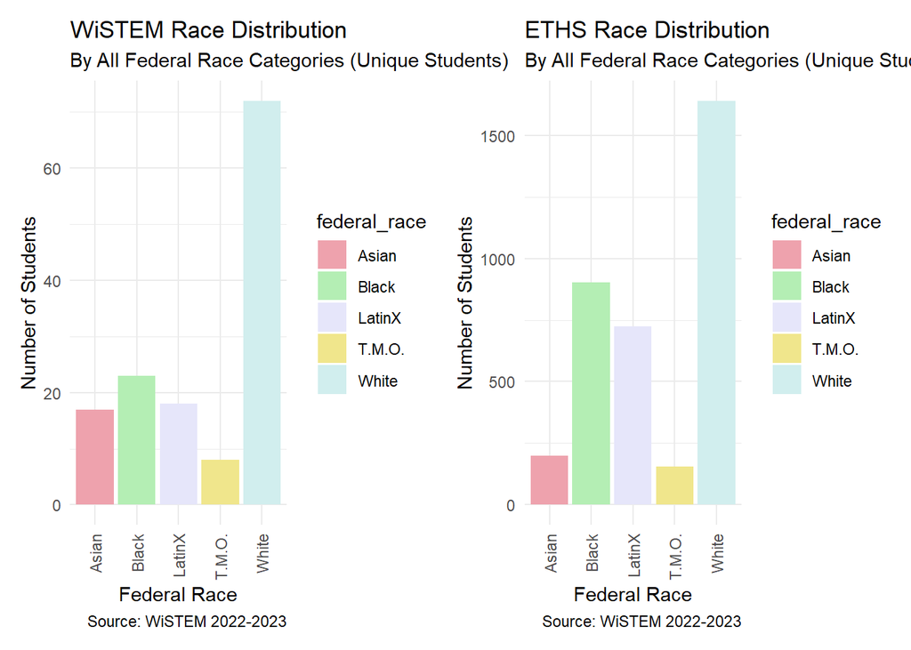

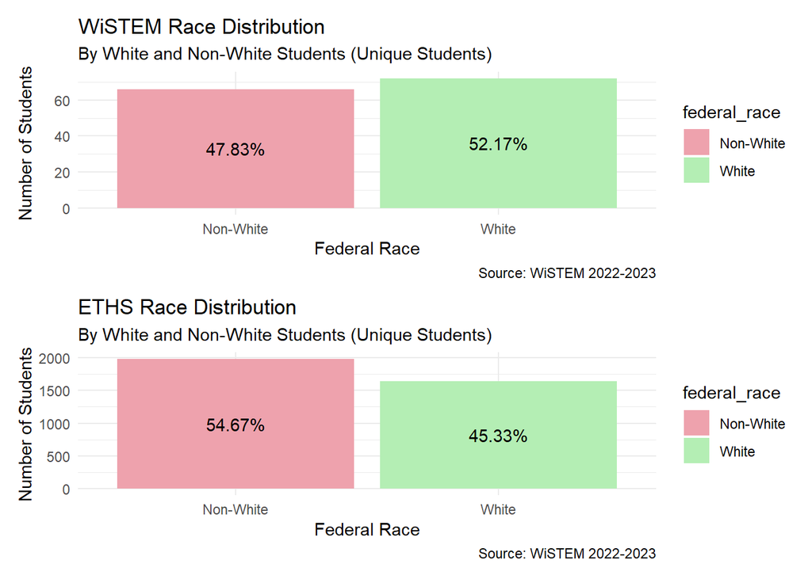

**Table for Comparing Race Distributions Between WiSTEM and ETHS (All Categories)**

Comparing Race Distributions (All Federal Race Categories) (Unique)

| program | federal_race | num_students | prop | percent |
| --- | --- | --- | --- | --- |
| eths | White | 1640 | 0.4532891 | 45.328911 |
| eths | Asian | 198 | 0.0547264 | 5.472637 |
| eths | Black | 902 | 0.2493090 | 24.930901 |
| eths | LatinX | 724 | 0.2001106 | 20.011056 |
| eths | T.M.O. | 154 | 0.0425650 | 4.256495 |
| wistem | White | 72 | 0.5217391 | 52.173913 |
| wistem | T.M.O. | 8 | 0.0579710 | 5.797101 |
| wistem | LatinX | 18 | 0.1304348 | 13.043478 |
| wistem | Black | 23 | 0.1666667 | 16.666667 |
| wistem | Asian | 17 | 0.1231884 | 12.318841 |

**Table for Comparing Race Distributions Between WiSTEM and ETHS (White and Non-White)**

Comparing Race Distributions (White and Non-White) (Unique)

| program | federal_race | num_students | prop | percent |
| --- | --- | --- | --- | --- |
| eths | White | 1640 | 0.4532891 | 45.32891 |
| eths | Non-White | 1978 | 0.5467109 | 54.67109 |
| wistem | White | 72 | 0.5217391 | 52.17391 |
| wistem | Non-White | 66 | 0.4782609 | 47.82609 |

## Race and Number of Meetings

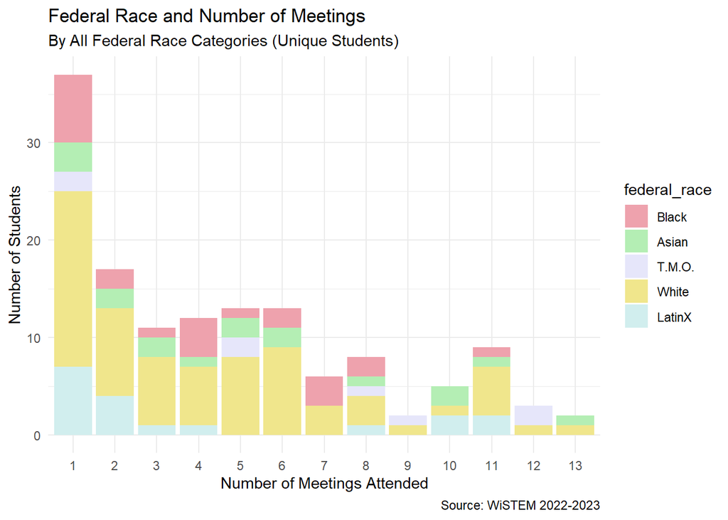

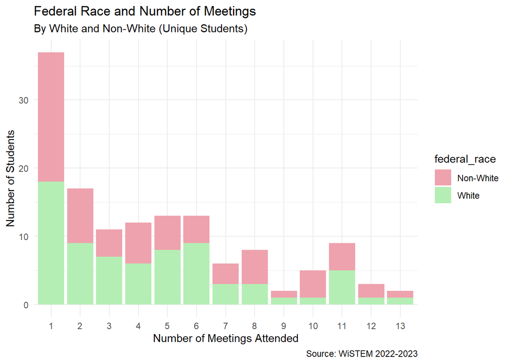

**Table for Federal Race and Number of Meeings Attended (All Categories)**

Race and Number of Meetings Attended (All Federal Race Categories) (Unique)

| federal_race | num_meetings | num_students |
| --- | --- | --- |
| Black | 1 | 7 |
| Black | 2 | 2 |
| Black | 3 | 1 |
| Black | 4 | 4 |
| Black | 5 | 1 |
| Black | 6 | 2 |
| Black | 7 | 3 |
| Black | 8 | 2 |
| Black | 11 | 1 |
| Asian | 1 | 3 |
| Asian | 2 | 2 |
| Asian | 3 | 2 |
| Asian | 4 | 1 |
| Asian | 5 | 2 |
| Asian | 6 | 2 |
| Asian | 8 | 1 |
| Asian | 10 | 2 |
| Asian | 11 | 1 |
| Asian | 13 | 1 |
| T.M.O. | 1 | 2 |
| T.M.O. | 5 | 2 |
| T.M.O. | 8 | 1 |
| T.M.O. | 9 | 1 |
| T.M.O. | 12 | 2 |
| White | 1 | 18 |
| White | 2 | 9 |
| White | 3 | 7 |
| White | 4 | 6 |
| White | 5 | 8 |
| White | 6 | 9 |
| White | 7 | 3 |
| White | 8 | 3 |
| White | 9 | 1 |
| White | 10 | 1 |
| White | 11 | 5 |
| White | 12 | 1 |
| White | 13 | 1 |
| LatinX | 1 | 7 |
| LatinX | 2 | 4 |
| LatinX | 3 | 1 |
| LatinX | 4 | 1 |
| LatinX | 8 | 1 |
| LatinX | 10 | 2 |
| LatinX | 11 | 2 |

**Table for Federal Race and Number of Meeings Attended (White and Non-White)**

Race and Number of Meetings Attended (White and Non-White) (Unique)

| federal_race | num_meetings | num_students |
| --- | --- | --- |
| Non-White | 1 | 19 |
| Non-White | 2 | 8 |
| Non-White | 3 | 4 |
| Non-White | 4 | 6 |
| Non-White | 5 | 5 |
| Non-White | 6 | 4 |
| Non-White | 7 | 3 |
| Non-White | 8 | 5 |
| Non-White | 9 | 1 |
| Non-White | 10 | 4 |
| Non-White | 11 | 4 |
| Non-White | 12 | 2 |
| Non-White | 13 | 1 |
| White | 1 | 18 |
| White | 2 | 9 |
| White | 3 | 7 |
| White | 4 | 6 |
| White | 5 | 8 |
| White | 6 | 9 |
| White | 7 | 3 |
| White | 8 | 3 |
| White | 9 | 1 |
| White | 10 | 1 |
| White | 11 | 5 |
| White | 12 | 1 |
| White | 13 | 1 |

## Race and Topic

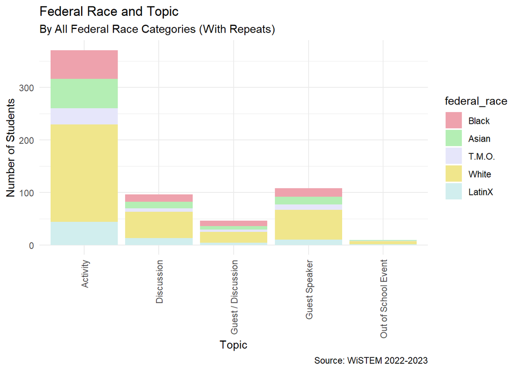

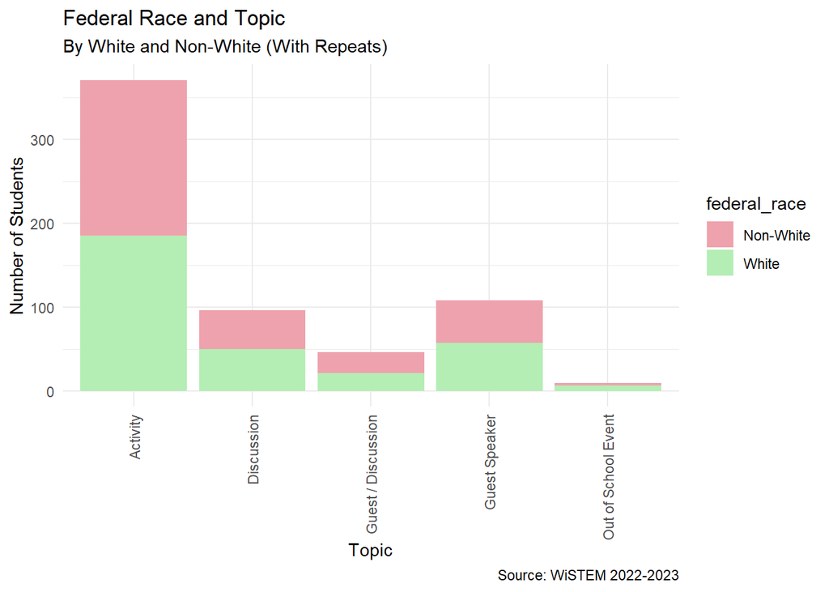

**Table for Federal Race and Topic (All Categories)**

| federal_race | topic | num_students |
| --- | --- | --- |
| Black | Activity | 55 |
| Black | Discussion | 14 |
| Black | Guest / Discussion | 10 |
| Black | Guest Speaker | 16 |
| Asian | Activity | 56 |
| Asian | Discussion | 12 |
| Asian | Guest / Discussion | 7 |
| Asian | Guest Speaker | 15 |
| Asian | Out of School Event | 1 |
| T.M.O. | Activity | 31 |
| T.M.O. | Discussion | 7 |
| T.M.O. | Guest / Discussion | 4 |
| T.M.O. | Guest Speaker | 10 |
| T.M.O. | Out of School Event | 1 |
| White | Activity | 185 |
| White | Discussion | 50 |
| White | Guest / Discussion | 21 |
| White | Guest Speaker | 57 |
| White | Out of School Event | 6 |
| LatinX | Activity | 44 |
| LatinX | Discussion | 13 |
| LatinX | Guest / Discussion | 4 |
| LatinX | Guest Speaker | 10 |
| LatinX | Out of School Event | 1 |

**Table for Federal Race and Topic (White and Non-White)**

| federal_race | topic | num_students |
| --- | --- | --- |
| Non-White | Activity | 186 |
| Non-White | Discussion | 46 |
| Non-White | Guest / Discussion | 25 |
| Non-White | Guest Speaker | 51 |
| Non-White | Out of School Event | 3 |
| White | Activity | 185 |
| White | Discussion | 50 |
| White | Guest / Discussion | 21 |
| White | Guest Speaker | 57 |
| White | Out of School Event | 6 |

# Attendance by Additional Characteristics

## Of All Unique Students

[figure not shown]

**Table for Additional Characteristics of All Unique Students**

Attendance Distribution by Additional Characteristics

| characteristic | applicable | num_students | prop | percent |
| --- | --- | --- | --- | --- |
| IEP | Yes | 6 | 0.0434783 | 4.347826 |
| IEP | No | 132 | 0.9565217 | 95.652174 |
| 504 Plan | Yes | 20 | 0.1449275 | 14.492754 |
| 504 Plan | No | 118 | 0.8550725 | 85.507246 |
| ESL | Yes | 6 | 0.0434783 | 4.347826 |
| ESL | No | 132 | 0.9565217 | 95.652174 |